# ¿Cuál es el precio justo? Nivel y dispersión geográfica de los precios mayoristas de alimentos en Colombia, 2024

Fase 1 — Análisis exploratorio, pregunta de investigación y diseño del estudio

Víctor Fabián Novoa Rojas — Maestría en Inteligencia Artificial, Universidad de La Sabana

14 de septiembre de 2026

# 1 Contexto y motivación

En Colombia el precio que paga un hogar por un alimento se forma mucho antes de llegar al punto de venta: se define en la central de abastos o la plaza de mercado donde el producto se transa al por mayor. El DANE monitorea ese eslabón a través del **SIPSA** (Sistema de Información de Precios y Abastecimiento del Sector Agropecuario), que recoge cotizaciones diarias en decenas de mercados mayoristas del país y las publica agregadas por mes.

La pregunta de fondo es vieja en economía y sigue abierta en el caso colombiano: si los mercados estuvieran perfectamente integrados, el precio de un mismo bien debería ser prácticamente el mismo en todo el territorio una vez descontados los costos de transporte — es la llamada **ley de precio único**. En la práctica no ocurre: la geografía quebrada, el estado de las vías, la concentración de la intermediación y la perecibilidad de cada producto hacen que el mismo kilo de alimento valga cosas muy distintas según dónde se compre.

Lo que este estudio agrega a esa discusión es una pregunta menos explorada: **no todos los alimentos se dispersan igual, y esa desigualdad parece depender del nivel de precio del propio producto**. Un bien barato y perecedero como el brócoli podría estar mucho más expuesto a la fragmentación territorial que un bien caro, estandarizado y fácil de transportar como la carne o un procesado. Contrastar esa intuición con datos es el objeto de este trabajo.

# 2 El conjunto de datos

| Atributo | Valor |
| --- | --- |
| Fuente | SIPSA — DANE, precios mayoristas mensuales |
| Cobertura temporal | Enero a diciembre de 2024 (12 meses) |
| Unidad de observación | Producto x mercado x mes |
| Registros | 54.042 |
| Productos | 349 |
| Mercados mayoristas | 80 |
| Ciudades / municipios | 59 |
| Departamentos | 24 |
| Grupos alimentarios | 8 |
| Valores faltantes | 0 |
| Registros duplicados | 0 |

El archivo original trae **seis columnas**: mes, grupo alimentario, producto, código CPC, mercado y precio promedio por kilogramo. De ellas solo una es cuantitativa. Para poder responder una pregunta que involucre dos variables numéricas fue necesario **derivar indicadores a partir de la estructura del panel**, y enriquecer el campo `Mercado` — que mezcla ciudad, departamento y nombre de plaza en un solo texto — en variables geográficas e institucionales separadas. Ese trabajo está documentado en `R/01_carga_y_enriquecimiento.R`.

## 2.1 Calidad de los datos

La base está completa en el sentido estricto: no hay valores faltantes ni registros duplicados en la llave `producto x mercado x mes`. Lo que sí existe es una **cobertura desbalanceada**, y esta es la restricción metodológica central del estudio:

| Indicador | Mediana | Mínimo | Máximo | Total |
| --- | --- | --- | --- | --- |
| Mercados en que se cotiza un producto | 10 | 1 | 46 | — |
| Productos cotizados en un mercado | 44 | 1 | 213 | — |
| Celdas del panel completo teórico | — | — | — | 335.040 |
| Celdas efectivamente observadas | — | — | — | 54.042 (16,1%) |

El panel observado ocupa apenas el 16% del panel teórico. No es un error de captura: refleja que cada plaza cotiza la canasta que efectivamente se transa en ella. La consecuencia práctica es que **la dispersión intermercado solo es comparable cuando un producto se cotiza en un número razonable de plazas**; por eso el estudio fija un umbral mínimo de 5 mercados por par producto-mes, que conserva 2.987 de los 4.137 pares disponibles (72,2%).

# 3 Análisis exploratorio de datos

## 3.1 La variable de precio está fuertemente sesgada

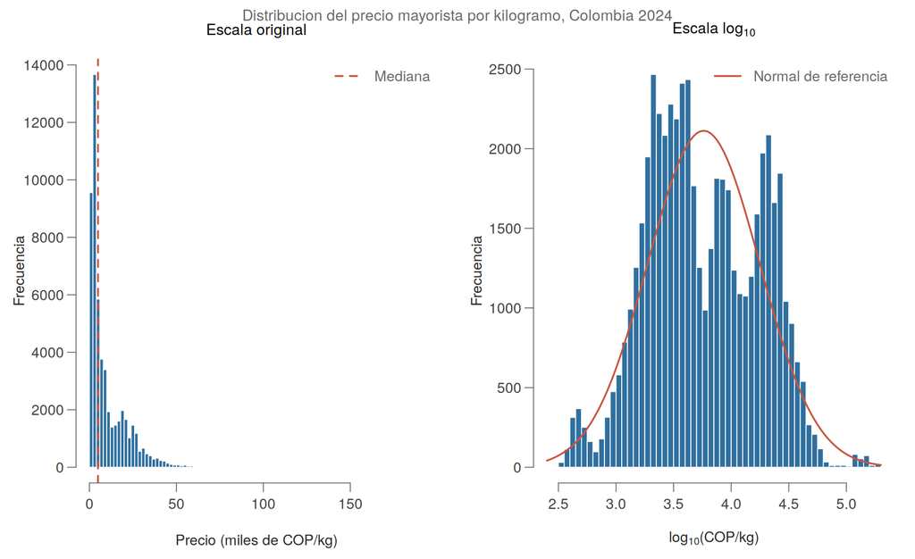

Figura 1. Distribución del precio mayorista por kilogramo en escala original y logarítmica.

| n | media | mediana | desv_est | cv_pct | minimo | q1 | q3 | maximo | rango_iq | asimetria | curtosis |
| --- | --- | --- | --- | --- | --- | --- | --- | --- | --- | --- | --- |
| 54042 | 10568.84 | 4945 | 13902.87 | 131.55 | 265 | 2434 | 15439.5 | 191528 | 13005.5 | 4.61 | 37.58 |

El precio mediano nacional es de $4.945 por kilogramo, pero la media ($10.569) la duplica: la distribución tiene una **asimetría de 4,61** y una curtosis de 37,6, propias de una variable de precios donde conviven tubérculos por menos de mil pesos el kilo y cortes de carne o procesados por encima de los cien mil.

Esto no es un defecto de los datos sino una característica de la variable, y tiene dos implicaciones que el diseño del estudio debe asumir:

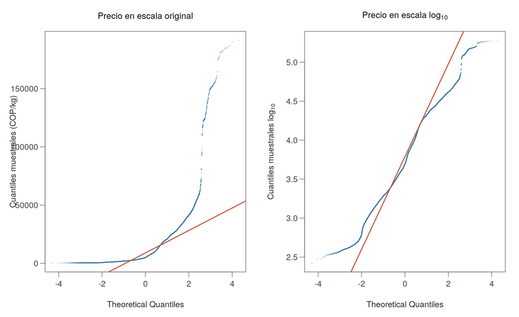

Figura 2. Gráfico cuantil-cuantil normal antes y después de la transformación logarítmica.

Bajo la regla de Tukey, el 4,1% de los registros sería “atípico” en escala original. Son productos legítimamente caros, no errores; **no se eliminan**, se analizan en escala logarítmica o comparándolos dentro de su propio grupo alimentario.

## 3.2 El precio depende fuertemente del grupo alimentario

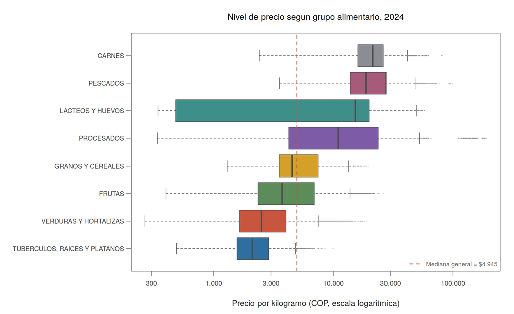

Figura 3. Nivel de precio por grupo alimentario (escala logarítmica).

| grupo | n | mediana | q1 | q3 | cv_pct |
| --- | --- | --- | --- | --- | --- |
| CARNES | 8685 | 21438.0 | 16063.0 | 26250.0 | 40.5 |
| PESCADOS | 2918 | 18806.5 | 13850.0 | 27571.5 | 60.5 |
| LACTEOS Y HUEVOS | 2321 | 15325.0 | 480.0 | 20000.0 | 104.7 |
| PROCESADOS | 8544 | 11006.5 | 4225.8 | 23835.2 | 132.4 |
| GRANOS Y CEREALES | 3615 | 4513.0 | 3514.5 | 7459.5 | 50.9 |
| FRUTAS | 12891 | 3724.0 | 2332.5 | 6925.5 | 71.2 |
| VERDURAS Y HORTALIZAS | 11112 | 2493.5 | 1648.0 | 4009.5 | 73.6 |
| TUBERCULOS, RAICES Y PLATANOS | 3956 | 2113.0 | 1569.0 | 2866.0 | 47.2 |

Entre el grupo más caro y el más barato hay exactamente **un orden de magnitud**: la mediana de carnes es 10,1 veces la de tubérculos, raíces y plátanos. Dos grupos merecen atención especial porque su caja es anormalmente ancha:

- **Lácteos y huevos** mezcla en una sola categoría el huevo (entre 341 y 627 COP/kg) y los quesos (mediana cercana a 19.000 COP/kg).
- **Procesados** reúne desde panela hasta productos de valor agregado alto.

Esta heterogeneidad interna es exactamente la razón por la que el grupo alimentario entra al estudio **como variable explicativa**, y no como un simple descriptor.

## 3.3 La dispersión geográfica: la segunda variable cuantitativa

Para medir cuánto varía el precio de un mismo producto entre mercados se calcula, para cada par **producto x mes**, el **coeficiente de variación intermercado**:

$$CV_{p,t} \;=\; 100 \times
\frac{s_{p,t}}{\bar{x}_{p,t}}$$

donde $\bar{x}_{p,t}$ y $s_{p,t}$ son la media y la desviación estándar del precio del producto $p$ en el mes $t$ a través de los mercados que lo cotizan. Al ser una medida **relativa**, permite comparar la dispersión de la papa con la del salmón sin que el nivel de precio contamine la comparación — que es justamente lo que se quiere poner a prueba.

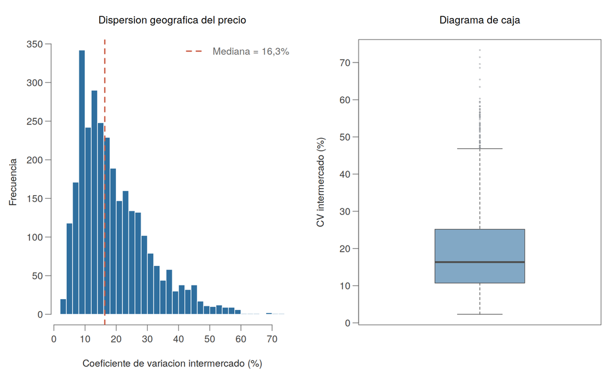

Figura 4. Distribución del coeficiente de variación intermercado.

| n | media | mediana | desv_est | cv_pct | minimo | q1 | q3 | maximo | rango_iq | asimetria | curtosis |
| --- | --- | --- | --- | --- | --- | --- | --- | --- | --- | --- | --- |
| 2987 | 19.25 | 16.34 | 11.14 | 57.88 | 2.31 | 10.71 | 25.17 | 73.35 | 14.46 | 1.18 | 1.37 |

El hallazgo descriptivo es contundente: en el par producto-mes típico el precio mayorista se desvía **16,3%** de su media nacional según el mercado donde se cotice, y el producto mediano se transa a un precio **1,75 veces más alto** en la plaza más cara que en la más barata del mismo mes. La ley de precio único no se cumple ni de lejos.

## 3.4 La dispersión tampoco es uniforme entre grupos

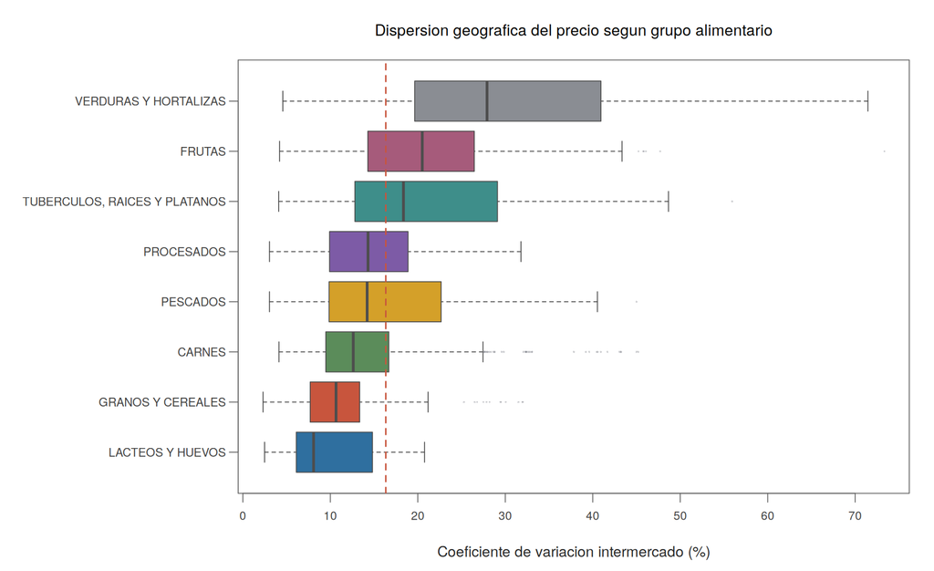

Figura 5. Dispersión geográfica del precio por grupo alimentario.

| grupo | n | media | ic95_inf | ic95_sup | mediana | q1 | q3 |
| --- | --- | --- | --- | --- | --- | --- | --- |
| VERDURAS Y HORTALIZAS | 557 | 30.0 | 28.79 | 31.11 | 27.9 | 19.6 | 40.9 |
| FRUTAS | 679 | 21.0 | 20.35 | 21.70 | 20.5 | 14.3 | 26.5 |
| TUBERCULOS, RAICES Y PLATANOS | 243 | 21.2 | 19.85 | 22.48 | 18.4 | 12.8 | 29.1 |
| PROCESADOS | 416 | 14.9 | 14.24 | 15.47 | 14.3 | 9.9 | 18.9 |
| PESCADOS | 264 | 16.4 | 15.39 | 17.37 | 14.2 | 9.9 | 22.7 |
| CARNES | 480 | 14.6 | 13.94 | 15.30 | 12.6 | 9.5 | 16.7 |
| GRANOS Y CEREALES | 228 | 11.7 | 10.93 | 12.41 | 10.7 | 7.7 | 13.3 |
| LACTEOS Y HUEVOS | 120 | 10.2 | 9.26 | 11.12 | 8.1 | 6.1 | 14.8 |

Verduras y hortalizas dispersa 3,4 veces más que lácteos y huevos. Los intervalos de confianza al 95% para la media de cada grupo **no se traslapan** entre los extremos, lo que anticipa que la diferencia no es producto del azar muestral.

## 3.5 Nivel frente a dispersión: el hallazgo central

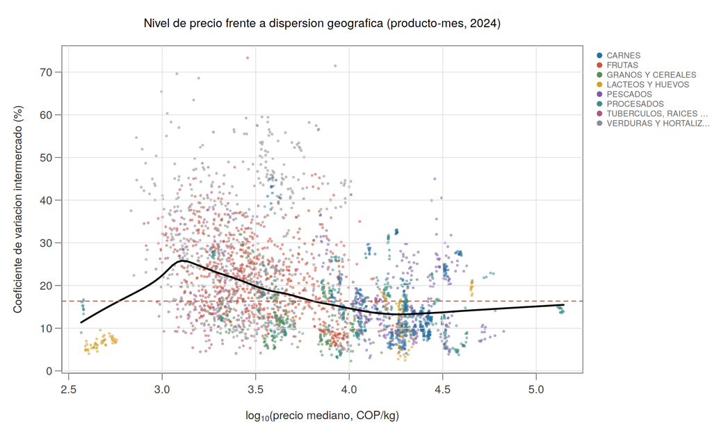

Figura 6. Relación entre el nivel de precio y la dispersión geográfica, por grupo alimentario.

La relación entre ambas cuantitativas es **negativa y moderada**:

| Medida | Coeficiente | IC 95% | valor p |
| --- | --- | --- | --- |
| Pearson sobre log10(precio) | -0,345 | [-0,376 ; -0,313] | < 2e-16 |
| Spearman sobre precio | -0,379 | — | < 2e-16 |

Leído por cuartiles de precio, sin suponer linealidad, el patrón es monótono:

| cuartil | n | media | mediana | desv_est |
| --- | --- | --- | --- | --- |
| Q1 (mas barato) | 747 | 24.1 | 23.5 | 11.6 |
| Q2 | 747 | 22.0 | 19.6 | 11.9 |
| Q3 | 746 | 17.3 | 15.3 | 10.3 |
| Q4 (mas caro) | 747 | 13.7 | 12.0 | 6.9 |

**Los alimentos más baratos son los que más varían de precio entre territorios.** El cuartil más económico casi duplica la dispersión del cuartil más caro. Es un resultado con sentido económico: los productos baratos suelen ser perecederos, de bajo valor por kilo y, por lo tanto, con un costo de transporte que pesa mucho sobre su precio final, lo que desincentiva el arbitraje entre plazas distantes.

Pero el gráfico revela algo más interesante todavía: **la relación se invierte dentro de al menos un grupo.**

| grupo | n | pearson_log | spearman |
| --- | --- | --- | --- |
| FRUTAS | 679 | -0.419 | -0.442 |
| GRANOS Y CEREALES | 228 | -0.331 | -0.295 |
| PROCESADOS | 416 | -0.188 | -0.245 |
| CARNES | 480 | -0.349 | -0.163 |
| PESCADOS | 264 | -0.173 | -0.160 |
| TUBERCULOS, RAICES Y PLATANOS | 243 | -0.098 | -0.068 |
| VERDURAS Y HORTALIZAS | 557 | -0.029 | -0.027 |
| LACTEOS Y HUEVOS | 120 | 0.630 | 0.528 |

En lácteos y huevos la correlación es **positiva y fuerte** (0,528 de Spearman), mientras que en frutas es la más negativa de todas (-0,442). Es decir, el signo de la relación depende del grupo: hay un **efecto de interacción**, no un efecto único. Este es precisamente el tipo de estructura que justifica un estudio que combine las dos cuantitativas con la variable categórica en lugar de analizarlas por separado.

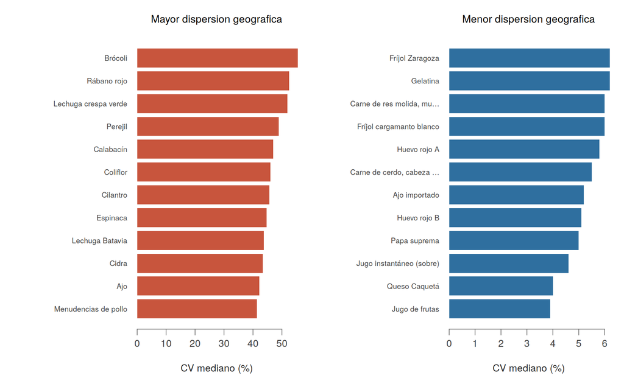

Figura 7. Productos con mayor y menor dispersión geográfica de precio.

## 3.6 Dónde se compra también importa

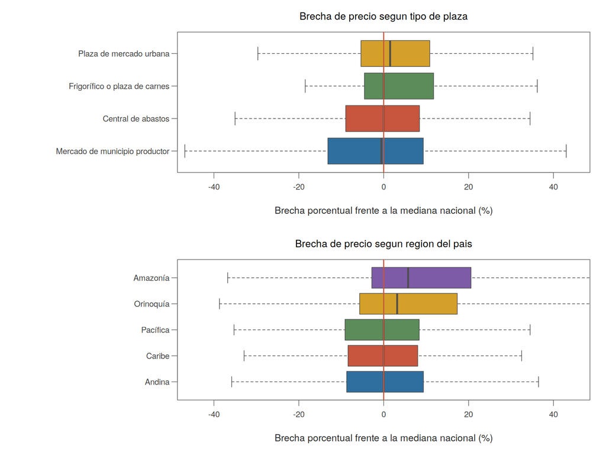

Figura 8. Brecha porcentual frente al precio nacional según tipo de plaza y región.

| tipo_plaza | n | media | mediana | q1 | q3 |
| --- | --- | --- | --- | --- | --- |
| Central de abastos | 28581 | 1.8 | 0.0 | -9.0 | 8.4 |
| Plaza de mercado urbana | 12970 | 4.5 | 1.5 | -5.3 | 10.9 |
| Mercado de municipio productor | 10872 | -1.0 | -0.6 | -13.2 | 9.3 |
| Frigorífico o plaza de carnes | 1619 | 7.4 | 0.0 | -4.5 | 11.8 |

| region | n | media | mediana | q1 | q3 |
| --- | --- | --- | --- | --- | --- |
| Andina | 29379 | 1.4 | 0.0 | -8.7 | 9.4 |
| Caribe | 8906 | 2.7 | 0.0 | -8.4 | 8.0 |
| Pacífica | 11917 | 0.4 | 0.0 | -9.1 | 8.4 |
| Orinoquía | 2979 | 9.4 | 3.2 | -5.7 | 17.3 |
| Amazonía | 861 | 13.0 | 5.7 | -2.8 | 20.6 |

Los **mercados de municipio productor** cotizan sistemáticamente por debajo de la referencia nacional y las **plazas urbanas** por encima: la diferencia entre comprar en el origen y comprar en destino es visible en los datos. En el eje regional, **Amazonía y Orinoquía pagan sobreprecios medianos de 5,7% y 3,2%** frente a las regiones centrales — el costo de la distancia y de la conectividad vial.

## 3.7 Comportamiento a lo largo del año

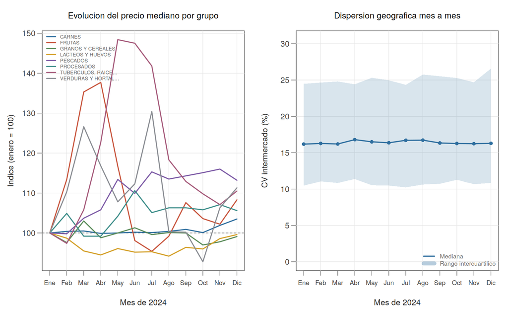

Figura 9. Evolución mensual del precio mediano por grupo y de la dispersión geográfica.

# 4 Pregunta de investigación

> **¿En qué medida el nivel de precio de un alimento explica la dispersión geográfica de su precio entre los mercados mayoristas de Colombia durante 2024, y cómo se modifica esa relación según el grupo alimentario y el tipo de plaza en que se transa?**

## 4.1 Por qué es una buena pregunta estadística

| Criterio | Cómo lo cumple |
| --- | --- |
| **Requiere recolectar y analizar datos** | No se puede responder por razonamiento: exige calcular dispersiones sobre 54.042 cotizaciones en 80 mercados. |
| **Involucra variabilidad** | La variabilidad *es* el objeto de estudio. El CV intermercado va de 2,3% a 73,3%. |
| **No es cerrada** | La respuesta es una magnitud con intervalo de confianza y un conjunto de contrastes por categoría, no un sí/no. |
| **Claridad** | Cada término está operacionalizado: “nivel de precio” = COP/kg; “dispersión” = CV intermercado; “grupo” y “tipo de plaza” tienen categorías definidas y exhaustivas. |
| **Viabilidad** | Los datos están disponibles, limpios y ya procesados; el análisis corre con R base en segundos. |
| **Medición cuantitativa** | Ambos conceptos centrales son numéricos y continuos, y admiten correlación, ANOVA y estimación por intervalos. |

## 4.2 Preguntas específicas derivadas

1. ¿Cuál es el precio mayorista promedio de los alimentos en Colombia en 2024 y con qué precisión puede estimarse por grupo alimentario?
2. ¿Cuánta dispersión geográfica de precio existe y qué intervalo de confianza tiene el CV medio nacional?
3. ¿Existe asociación significativa entre el nivel de precio y la dispersión geográfica? ¿Cuál es su signo y su magnitud?
4. ¿Difiere esa asociación entre grupos alimentarios? ¿Es significativa la interacción?
5. ¿Las centrales de abastos ofrecen precios significativamente distintos de los de las plazas urbanas y los mercados de municipio productor?

# 5 Definición de las variables

## 5.1 Variables cuantitativas

| Variable | Definición | Unidad | Nivel | Origen |
| --- | --- | --- | --- | --- |
| `precio_kg` | Precio promedio mensual por kilogramo del producto en el mercado | COP/kg | Continua, razón | Original |
| `cv_pct` | Coeficiente de variación del precio del producto entre mercados, en el mes | % | Continua, razón | **Derivada** |
| `brecha_pct` | Desviación porcentual del precio de la plaza frente a la mediana nacional del producto en ese mes | % | Continua, intervalo | **Derivada** |
| `n_mercados` | Número de mercados que cotizan el producto en el mes | conteo | Discreta, razón | **Derivada** |

Las dos primeras son las **variables centrales** de la pregunta: `precio_kg` mide el *nivel* y `cv_pct` la *dispersión*. Las otras dos permiten controlar y matizar los resultados.

## 5.2 Variables cualitativas

| Variable | Definición | Categorías | Origen |
| --- | --- | --- | --- |
| `grupo` | Grupo alimentario | 8 (carnes, frutas, verduras, …) | Original |
| `tipo_plaza` | Naturaleza institucional del mercado | 4 (central de abastos, plaza urbana, municipio productor, frigorífico) | **Derivada** |
| `region` | Región natural del país | 5 (Andina, Caribe, Pacífica, Orinoquía, Amazonía) | **Derivada** |
| `mes` | Mes de cotización | 12 | Original |
| `producto` | Producto específico | 349 | Original |

Las variables derivadas se construyeron descomponiendo el campo `Mercado`, que combina ciudad, departamento y nombre de plaza en una sola cadena de texto. El criterio de clasificación del tipo de plaza y la asignación regional están documentados en el script de carga y en el diccionario `salidas/tablas/00_diccionario_mercados.csv`, de modo que la codificación sea auditable y reproducible.

## 5.3 Unidades de análisis

El estudio trabaja en dos niveles, y es importante no confundirlos:

- **Nivel registro** (54.042 observaciones): producto x mercado x mes. Es la unidad para analizar `precio_kg` y `brecha_pct`.
- **Nivel producto-mes** (2.987 observaciones con al menos 5 mercados): es la unidad para analizar `cv_pct`, porque la dispersión es una propiedad del conjunto de mercados, no de una cotización individual.

# 6 Justificación del estudio

## 6.2 ¿A quién puede beneficiar conocer estos datos?

- **Hogares y consumidores.** Saber que el mismo alimento cuesta en mediana 1,75 veces más en una plaza que en otra, y que las verduras son el grupo donde más se paga por comprar en el lugar equivocado, es información accionable.
- **Pequeños productores.** Los mercados de municipio productor cotizan por debajo de la referencia nacional; cuantificar esa brecha es cuantificar el margen que se queda en la intermediación.
- **Gestores de política pública** (DANE, Ministerio de Agricultura, alcaldías). Identificar qué productos y qué regiones concentran la fragmentación permite priorizar inversión en vías terciarias, centros de acopio y sistemas de información de precios.
- **Comerciantes y operadores logísticos.** La dispersión es, en términos operativos, una señal de oportunidad de arbitraje y de riesgo de inventario.
- **Programas de compras públicas** (alimentación escolar, bancos de alimentos), que pueden usar un precio de referencia estadísticamente fundamentado en lugar de una cotización puntual.

## 6.3 ¿Qué se puede aprender?

Una caracterización cuantificada y con medida de incertidumbre de la integración del mercado alimentario colombiano: cuánta dispersión hay, qué la estructura, qué productos y territorios están más expuestos, y si las diferencias observadas entre grupos y plazas resisten un contraste formal o son ruido muestral.

## 6.4 ¿Qué decisiones podrían tomarse?

| Actor | Decisión informada por el estudio |
| --- | --- |
| Comprador institucional | Fijar un precio de referencia con intervalo de confianza en vez de una cotización única |
| Planificador de infraestructura | Priorizar corredores hacia las regiones con mayor sobreprecio (Amazonía, Orinoquía) |
| Productor | Elegir plaza de venta comparando la brecha típica por tipo de mercado |
| Analista de riesgo / abastecimiento | Anticipar en qué grupos la variabilidad de precio hace más costoso el error de aprovisionamiento |
| Diseñador de política de información | Focalizar la difusión de precios en los productos donde la dispersión indica mayor asimetría de información |

## 6.5 Validez del estudio en su contexto

El estudio es válido para el **eslabón mayorista** del sistema alimentario colombiano en 2024, y esa delimitación debe hacerse explícita:

- **Validez de la fuente.** SIPSA es el sistema oficial de información de precios agropecuarios del DANE, con metodología pública y recolección continua en las plazas. No se trata de una muestra de conveniencia.
- **Cobertura.** 80 mercados en 24 departamentos y las cinco regiones naturales; incluye las principales centrales de abastos del país, que concentran la mayor parte del volumen transado.
- **Comparabilidad.** Todos los precios están expresados en la misma unidad (COP por kilogramo), lo que hace comparables productos vendidos originalmente por unidad, atado o bulto.
- **Limitaciones reconocidas.** (i) No es una muestra probabilística de plazas, por lo que la inferencia se interpreta como válida para el universo de mercados monitoreados y no para *todo* mercado del país; (ii) el precio está en términos nominales, sin deflactar; (iii) el dato es un promedio mensual, de modo que se pierde la volatilidad intramensual; (iv) no se observan volúmenes transados, lo que impide ponderar por importancia económica; (v) la clasificación de tipo de plaza es una construcción propia a partir del nombre del mercado y, como toda codificación, admite discusión — por eso se publica el diccionario completo.

# 7 Objetivos del estudio

## 7.1 Objetivo general

**Analizar** la relación entre el nivel de precio de los alimentos y la dispersión geográfica de sus precios en los mercados mayoristas de Colombia durante 2024, **determinando** si dicha relación se modifica según el grupo alimentario y el tipo de plaza de comercialización.

## 7.2 Objetivos específicos

1. **Estimar**, mediante intervalos de confianza al 95%, el precio mayorista promedio por kilogramo y el coeficiente de variación intermercado medio, tanto a nivel nacional como por grupo alimentario.
2. **Determinar** la existencia, el signo y la magnitud de la asociación entre el nivel de precio y la dispersión geográfica, y **comparar** si esa asociación difiere significativamente entre los ocho grupos alimentarios.
3. **Comparar** la brecha de precio frente a la referencia nacional entre los distintos tipos de plaza y regiones del país, identificando en qué categorías las diferencias son estadísticamente significativas.

# 8 Anticipo de la fase inferencial

El análisis exploratorio orienta las técnicas de la siguiente fase y advierte sus supuestos:

| Contraste | Estadístico | Resultado |
| --- | --- | --- |
| Kruskal-Wallis: CV ~ grupo alimentario | H = 818,8 | p < 2e-16 |
| ANOVA de un factor: CV ~ grupo alimentario | F = 180,1 (eta cuadrado = 0,297) | p < 2e-16 |
| Kruskal-Wallis: brecha ~ tipo de plaza | H = 549,6 | p < 2e-16 |
| IC 95% del CV intermercado medio | 19,25% | [18,85% ; 19,65%] |

Estos contrastes son **preliminares** y se reportan aquí solo como evidencia de que la pregunta es abordable, no como resultados definitivos. Tres advertencias metodológicas quedan registradas para la fase siguiente:

- **La normalidad no se cumple en escala original.** Toda prueba paramétrica sobre `precio_kg` debe hacerse sobre su logaritmo o acompañarse de su equivalente no paramétrico, como se hizo arriba.
- **Las observaciones no son independientes.** El mismo producto aparece doce veces (una por mes) y el mismo mercado cientos de veces. La fase inferencial debe considerar esta estructura anidada; ignorarla subestimaría los errores estándar.
- **Los tamaños muestrales son muy grandes**, de modo que casi cualquier diferencia resultará significativa. Por eso se reportan **tamaños de efecto** (eta cuadrado, coeficientes de correlación) junto a los valores p.

# 9 Reproducibilidad

Todo el análisis corre con **R base**, sin paquetes externos, para que sea reproducible en cualquier instalación:

```
proyecto/
├── datos/            mensual_24.csv + bases procesadas (.rds)
├── R/
│   ├── 00_utilidades.R                funciones auxiliares y estilo gráfico
│   ├── 01_carga_y_enriquecimiento.R   lectura, depuración, variables derivadas
│   └── 02_analisis_exploratorio.R     AED completo
├── salidas/
│   ├── figuras/      9 figuras en PNG
│   ├── tablas/       12 tablas en CSV
│   └── log_aed.txt   salida de consola del análisis
├── informe/          este documento
└── ejecutar_todo.R   reproduce el pipeline completo
```

Para reproducirlo: abrir el proyecto en Visual Studio Code y ejecutar `source("ejecutar_todo.R")` desde la raíz.

# 10 Referencias

- DANE. *Sistema de Información de Precios y Abastecimiento del Sector Agropecuario (SIPSA) — Componente de Precios Mayoristas.* Bogotá: DANE. Microdatos disponibles en https://microdatos.dane.gov.co/index.php/catalog/776
- DANE. *Boletín técnico SIPSA — precios mayoristas.* Bogotá: DANE, 2024.
- Rodríguez Revilla, R. (2020). *Introducción a la microeconometría básica con aplicaciones.* Bogotá: Siglo del Hombre Editores.
- Tukey, J. W. (1977). *Exploratory Data Analysis.* Reading: Addison-Wesley.